# index

Jennifer Bone, Jennifer Kidson, Julia Paltseva

January 27, 2016

# Citizen Monitoring

## Types of data

Data collected will consist of text survey responses. Information will include phone numbers, timestamp, location information, demographic information, and a survey response, which may be numeric or text. Data will be coded to ensure anonymity of respondents.

The data will be categorized according to which survey question they are answering. This will be done with the timestamp data that comes in with each survey response. Once responses are separated into the proper questions, summary statistics will be generated for each one.

## Data and metadata standards

Metadata will include explanations of each of the following category headings: nominated, zone, years_zone, gender, age, and satisfaction.

## Policies for access and sharing

Since some versions of this data are tied to specific survey respondents (via telephone number) it should not be shared in a raw format. Statistics generated from the data may be shared in accordance with PI’s instructions.

## Policies and provisions for re-use, re-distribution

To be specified by PI.

## Plans for archiving and preservation of access

To be specified by PI.

## Data Question

How many women are very satisfied with solid waste collection?

```r
# load libraries
library(readr)
library(dplyr)
# read in csv
response = read.csv('data/ugandasms.csv')

# using dplyr
response %T>%                          # note tee operator %T>% for glimpse
  glimpse() %>%                        # view data
  select(gender, satis) %>%            # limit columns
  filter(gender  == 'female') %>%      # limit rows
  group_by(satis) %>%                  # get count by first grouping
  summarize(n = n()) %>%               # then summarize
  write_csv('data/f_satis.csv')        # write out csv
```

```
## Observations: 1,040
## Variables: 6
## $ Nominated  (fctr) yes, no, yes, yes, yes, no, yes, yes, yes, no, no,...
## $ Zone       (fctr) LUGOBA, KISOWERA, KISOWERA, GOOD HOPE, LUGOBA, COR...
## $ years_zone (int) 6, 30, 15, 1, 2, 3, 3, 13, 1, 2, 9, 35, 10, 4, 35, ...
## $ gender     (fctr) female, female, male, female, male, female, male, ...
## $ age        (int) 30, 40, 29, 42, 23, 30, 26, 32, 25, 22, 30, 35, 29,...
## $ satis      (fctr) very_dissatisf, satisfied, satisfied, very_satisfi...
```

```r
  f_satis = read.csv('data/f_satis.csv')   #
  head(f_satis)
```

```
##            satis   n
## 1   dissatisfied 122
## 2 neither_satisf  48
## 3      satisfied 118
## 4 very_dissatisf 132
## 5 very_satisfied  22
```

What is the age distribution of survey participants?

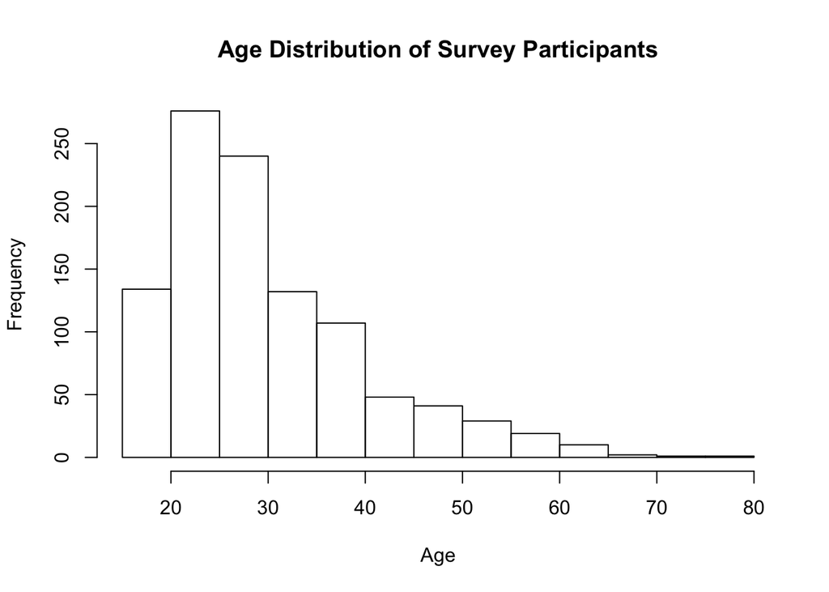

```r
#read in csv
response2 = read.csv('data/ugandasms.csv')

hist(response2$age, main = "Age Distribution of Survey Participants", xlab = "Age", ylab = "Frequency")
```

```r
# load libraries
library(readr)
library(dplyr)

#read in csv
response2 = read.csv('data/ugandasms.csv')

response2 %T>%                         # note tee operator %T>% for glimpse
  glimpse() %>%                        # view data
  select(gender, satis) %>%            # limit columns
  filter(gender  == 'male') %>%        # limit rows
  group_by(satis) %>%                  # get count by first grouping
  summarize(n = n()) %>%               # then summarize
  write_csv('data/m_dissat.csv')       # write out csv
```

```
## Observations: 1,040
## Variables: 6
## $ Nominated  (fctr) yes, no, yes, yes, yes, no, yes, yes, yes, no, no,...
## $ Zone       (fctr) LUGOBA, KISOWERA, KISOWERA, GOOD HOPE, LUGOBA, COR...
## $ years_zone (int) 6, 30, 15, 1, 2, 3, 3, 13, 1, 2, 9, 35, 10, 4, 35, ...
## $ gender     (fctr) female, female, male, female, male, female, male, ...
## $ age        (int) 30, 40, 29, 42, 23, 30, 26, 32, 25, 22, 30, 35, 29,...
## $ satis      (fctr) very_dissatisf, satisfied, satisfied, very_satisfi...
```

```r
  summary(response2)
```

```
##  Nominated      Zone       years_zone        gender         age
##  no :504   ZONE I : 24   Min.   : 1.000   female:442   Min.   :18.0
##  yes:536   ZONE V : 22   1st Qu.: 2.000   male  :598   1st Qu.:23.0
##            CHURCH : 18   Median : 5.000                Median :28.0
##            LUGOBA : 15   Mean   : 9.192                Mean   :30.5
##            LUBIRI : 14   3rd Qu.:13.000                3rd Qu.:35.0
##            B 9    : 13   Max.   :65.000                Max.   :76.0
##            (Other):934
##             satis
##  dissatisfied  :320
##  neither_satisf:124
##  satisfied     :270
##  very_dissatisf:283
##  very_satisfied: 43
##
##
```

```r
library(dplyr)
library(readr)
#read in csv
response3=read.csv('data/ugandasms.csv')
View(response3)

#using dplyr
response3 %T>%
  select(satis,Zone) %>%
  filter(satis == "very_dissatisf") %>%
  group_by(Zone) %>%
  summarize(n = n()) %>%
  write_csv('data/zonedissatis.csv')
  summary(response3)
```

```
##  Nominated      Zone       years_zone        gender         age
##  no :504   ZONE I : 24   Min.   : 1.000   female:442   Min.   :18.0
##  yes:536   ZONE V : 22   1st Qu.: 2.000   male  :598   1st Qu.:23.0
##            CHURCH : 18   Median : 5.000                Median :28.0
##            LUGOBA : 15   Mean   : 9.192                Mean   :30.5
##            LUBIRI : 14   3rd Qu.:13.000                3rd Qu.:35.0
##            B 9    : 13   Max.   :65.000                Max.   :76.0
##            (Other):934
##             satis
##  dissatisfied  :320
##  neither_satisf:124
##  satisfied     :270
##  very_dissatisf:283
##  very_satisfied: 43
##
##
```